# 16S Biome Donors Study Descriptive Analysis

Anna Korda

2025-05-20

## **A 16S study with Healthy Donor Samples**

This study (https://www.ebi.ac.uk/ena/browser/view/PRJEB41316) profiles the gut microbiome of carefully screened stool donors from a universal stool bank, using 16S rRNA sequencing on 200 samples from 86 donors. With **detailed lifestyle metadata and strict donor selection**, it offers a rare and **valuable reference for defining healthy gut microbiome baselines**. We used their official pipeline from OpenBiome’s Github https://github.com/openbiome/donors-16s/tree/v1.1, running the full Snakemake workflow and performing additional analysis to identify the baseline healthy control samples for our pipeline creation.

The objective is to conduct a **descriptive analysis of the donor dataset by calculating diversity metrics and exploring their distribution.** **Based on this exploration, we may apply filtering criteria to define a final set of healthy control samples.** The resulting distribution will serve as a reference framework for assessing other samples.

*This study was not available in MGnify

```r
library(tidyverse)
library(readxl)
library(vegan)
library(compositions)
library(cowplot)
library(robustbase)
library(gridExtra)
library(SummarizedExperiment)
library(phyloseq)
library(knitr)
library(kableExtra)
library(ggplot2)
library(tibble)
```

```r
# Load metadata
tech <- read_tsv("technical_metadata.tsv", col_types = cols(.default = "c"))
sample_map <- read_csv("metadata.csv", col_types = cols(.default = "c"))
donor_health <- read_excel("donor_health_data.xlsx")

# Clean column names and whitespace
colnames(donor_health) <- trimws(colnames(donor_health))
colnames(tech) <- trimws(colnames(tech))
colnames(sample_map) <- trimws(colnames(sample_map))

# Clean key columns
tech$sample_alias <- trimws(tech$sample_alias)
sample_map$sample_id <- trimws(sample_map$sample_id)
sample_map$donor <- trimws(sample_map$donor)
donor_health$`Publication Donor Code` <- trimws(donor_health$`Publication Donor Code`)


# Merge
sample_metadata <- sample_map %>%
  left_join(tech, by = c("sample_id" = "sample_alias")) %>%
  select(-library_name, -study_alias, -experiment_alias,
         -fastq_md5, -fastq_ftp, -fastq_galaxy,
         -submitted_aspera, -broker_name) %>%
  left_join(donor_health, by = c("donor" = "Publication Donor Code"))

# SAFELY rename outside the pipe
colnames(sample_metadata)[colnames(sample_metadata) == "Donor age"] <- "age"
colnames(sample_metadata)[colnames(sample_metadata) == "Donor Sex"] <- "sex"
colnames(sample_metadata)[colnames(sample_metadata) == "Height (in)"] <- "height_in"
colnames(sample_metadata)[colnames(sample_metadata) == "Height (cm)"] <- "height_cm"
colnames(sample_metadata)[colnames(sample_metadata) == "Weight (lbs)"] <- "weight_lbs"
colnames(sample_metadata)[colnames(sample_metadata) == "Weight (kgs)"] <- "weight_kg"
colnames(sample_metadata)[colnames(sample_metadata) == "Donor Waist circumference (in)"] <- "waist_circumference_in"
colnames(sample_metadata)[colnames(sample_metadata) == "Donor BMI"] <- "bmi"
colnames(sample_metadata)[colnames(sample_metadata) == "List of medications taken by donor (If any)"] <- "medications"
colnames(sample_metadata)[colnames(sample_metadata) == "List of dietary supplements taken by donor (if any)"] <- "supplements"
colnames(sample_metadata)[colnames(sample_metadata) == "List of probiotics taken by donor (if any)"] <- "probiotics"
colnames(sample_metadata)[colnames(sample_metadata) == "Information on donor's normal diet, including foods avoided (if any)"] <- "diet_info"
colnames(sample_metadata)[colnames(sample_metadata) == "Donor's known allergies (if any)"] <- "allergies"
colnames(sample_metadata)[colnames(sample_metadata) == "Donor's average weekly alcohol usage (if known)"] <- "alcohol_usage"


sample_metadata <- sample_metadata %>%
  mutate(across(where(is.character), ~ na_if(., "N/A")))
```

```r
#Load taxonomy file
taxonomy <- read_tsv("taxonomy.tsv")

taxonomy_split <- taxonomy %>%
  separate(Taxon, into = c("Kingdom", "Phylum", "Class", "Order", "Family", "Genus", "Species"),
           sep = "; ", fill = "right")


# Keep Feature ID as rownames and keep Confidence
taxonomy_rowdata <- taxonomy_split %>%
  column_to_rownames("Feature ID") %>%
  as.data.frame()

otu_table <- read_tsv("otu_table.tsv", skip = 1)  # Skip the comment line

otu_matrix <- otu_table %>%
  column_to_rownames("#OTU ID") %>%
  as.matrix()

# match sample metadata
sample_metadata_matched <- sample_metadata %>%
  filter(sample_id %in% colnames(otu_matrix)) %>%
  column_to_rownames("sample_id") %>%
  .[colnames(otu_matrix), ]

# match taxonomy-otu
taxonomy_rowdata_matched <- taxonomy_rowdata[rownames(otu_matrix), ]

#Build summarize experiment object

donors_se <- SummarizedExperiment(
  assays = list(counts = otu_matrix),
  colData = sample_metadata_matched,
  rowData = taxonomy_rowdata_matched
)

#Add some object metadata
metadata(donors_se)$source <- "OpenBiome donor dataset (2021 release)"
metadata(donors_se)$classifier_version <- "QIIME2-trained SILVA classifier"
metadata(donors_se)$rep_seqs_filtered <- FALSE


#Save the SummarizedExperimentObject
saveRDS(donors_se, "openbiome_se_full.rds")
```

Summary of the object we created for the whole dataset

Table: Summary of `donors_se` object

| Element | Value |
| --- | --- |
| Features (OTUs/ASVs) | 37261 |
| Samples | 197 |
| Assay(s) | counts |
| Taxonomic columns | 8 |
| Sample metadata columns | 41 |
| Metadata entries | 3 |

## Technical/Quality Check

Now we will explore our SummarizedExperimentObject to see what is missing and what is not

```r
health_vars <- c(
  "age", "sex", "height_in", "height_cm", "weight_lbs", "weight_kg",
  "waist_circumference_in", "bmi", "medications", "supplements", "probiotics",
  "diet_info", "allergies", "alcohol_usage"
)

coldata <- as.data.frame(colData(donors_se))

health_na_summary <- data.frame(
  Variable = health_vars,
  Total = nrow(coldata),
  Not_Reported = sapply(coldata[health_vars], function(x) sum(is.na(x))),
  Reported = sapply(coldata[health_vars], function(x) sum(!is.na(x)))
) %>%
  mutate(Not_Reported_Percent = round((Not_Reported / Total) * 100, 1)) %>%
  arrange(desc(Not_Reported_Percent))

kable(health_na_summary, caption = "Summary of Donor Health Metadata Availability")
```

Summary of Donor Health Metadata Availability

|  | Variable | Total | Not_Reported | Reported | Not_Reported_Percent |
| --- | --- | --- | --- | --- | --- |
| probiotics | probiotics | 197 | 185 | 12 | 93.9 |
| medications | medications | 197 | 167 | 30 | 84.8 |
| allergies | allergies | 197 | 124 | 73 | 62.9 |
| diet_info | diet_info | 197 | 121 | 76 | 61.4 |
| supplements | supplements | 197 | 109 | 88 | 55.3 |
| waist_circumference_in | waist_circumference_in | 197 | 42 | 155 | 21.3 |
| height_in | height_in | 197 | 1 | 196 | 0.5 |
| height_cm | height_cm | 197 | 1 | 196 | 0.5 |
| weight_lbs | weight_lbs | 197 | 1 | 196 | 0.5 |
| weight_kg | weight_kg | 197 | 1 | 196 | 0.5 |
| bmi | bmi | 197 | 1 | 196 | 0.5 |
| age | age | 197 | 0 | 197 | 0.0 |
| sex | sex | 197 | 0 | 197 | 0.0 |
| alcohol_usage | alcohol_usage | 197 | 0 | 197 | 0.0 |

```r
coldata %>%
  filter(is.na(bmi)) %>%
  rownames()
```

```
## [1] "sample063"
```

Now we can take a look at the criteria taken into account for this study in order to decide if we need to apply further filtering or not.

```r
# Load the Excel file
criteria <- read_excel("exclusion_criteria_comparison.xlsx", sheet = 1)

# Rename columns for clarity
colnames(criteria)[1:2] <- c("Criterion", "OpenBiome")

# Define target values to match
target_values <- c("X", "> 30", "serological liver panel", "Only asthma / allergies")

# Filter based on OpenBiome criteria
openbiome_filtered <- criteria %>%
  filter(OpenBiome %in% target_values) %>%
  select(Criterion, OpenBiome)

# Print as HTML table
kable(openbiome_filtered, caption = "OpenBiome Exclusion Criteria")
```

OpenBiome Exclusion Criteria

| Criterion | OpenBiome |
| --- | --- |
| Vitals outside normal range | X |
| Active cigarette smoking | X |
| BMI | > 30 |
| Bowel movement frequency / consistency / other GI status | X |
| Diet | X |
| Contact with hospital / long term care settings | X |
| Alcohol use | X |
| Tobacco use | X |
| Drug use | X |
| Recent tattoo / piercing | X |
| Incarceration for more than 72 hours | X |
| Sexual behavior | X |
| Travel history | X |
| Inflammatory bowel disease (IBD) | X |
| Irritable bowel syndrome (IBS) | X |
| Chronic constipation / diarrhea | X |
| Celiac disease | X |
| H. pylori infection | X |
| Peptic ulcer disease | X |
| Congenital or chronic liver disease | serological liver panel |
| Blood in stool | X |
| Other GI conditions | X |
| Thyroid disease | X |
| Inflammatory arthritis | X |
| Connective tissue disease | X |
| Psoriasis | X |
| Alopecia | X |
| Chronic skin conditions | X |
| Chronic autoimmune conditions | X |
| Asthma | X |

[output cut: 91 more lines]

## **First Insights**

**Based on the exclusion criteria already applied by OpenBiome, which are comprehensive and stringent** (e.g., BMI > 30, active smoking, serological liver panel, medication use, etc.), we believe that **applying additional overly strict filters may not be necessary.** Instead, a more **minimal and transparent filtering strategy could be applied to retain a sufficient number of healthy samples while maintaining confidence in their health status (sample063)**.

Specifically, we propose to:

- **Remove the single sample with missing BMI since this is a core variable for defining health status.**
- **Optionally, exclude samples with reported medications, as a precaution to avoid potential confounders and since they are not a lot.**

This approach strikes a balance between caution and sample retention. It can e**asily be revised in the future based on specific analytical goals.** Using this filtered set of plausibly healthy donors, we can now proceed to compute alpha diversity and explore its distribution across these samples, which will serve as a baseline for comparison.

## Exploratory Analysis of the Dataset

```r
# Clean and format colData
coldata <- as.data.frame(colData(donors_se)) %>%
  filter(!is.na(bmi), !is.na(sex), !is.na(age)) %>%
  mutate(
    sex = as.character(sex),
    age = as.numeric(age),
    bmi = as.numeric(bmi)
  )

# 1. Sex distribution
sex_dist <- coldata %>%
  group_by(sex) %>%
  summarise(n = n()) %>%
  mutate(Percent = round(n / sum(n) * 100, 1),
         Variable = "Sex", Level = sex) %>%
  select(Variable, Level, n, Percent)

# 2. Age group distribution
age_dist <- coldata %>%
  mutate(age_group = cut(age, breaks = c(17, 30, 45, 60, Inf),
                         labels = c("18–30", "31–45", "46–60", "61+"),
                         right = TRUE)) %>%
  group_by(age_group) %>%
  summarise(n = n()) %>%
  mutate(Percent = round(n / sum(n) * 100, 1),
         Variable = "Age Group", Level = as.character(age_group)) %>%
  select(Variable, Level, n, Percent)

# 3. BMI category distribution
bmi_dist <- coldata %>%
  mutate(bmi_group = cut(bmi, breaks = c(-Inf, 18.5, 25, 30, Inf),
                         labels = c("Underweight", "Normal", "Overweight", "Obese"),
                         right = FALSE)) %>%
  group_by(bmi_group) %>%
  summarise(n = n()) %>%
  mutate(Percent = round(n / sum(n) * 100, 1),
         Variable = "BMI Category", Level = as.character(bmi_group)) %>%
  select(Variable, Level, n, Percent)

# Combine all into one table
combined_summary <- bind_rows(sex_dist, age_dist, bmi_dist)

# Display in a single knitr table
kable(combined_summary, caption = "Combined Distribution of Donor Health Variables (%)")
```

Combined Distribution of Donor Health Variables (%)

| Variable | Level | n | Percent |
| --- | --- | --- | --- |
| Sex | F | 82 | 41.8 |
| Sex | M | 114 | 58.2 |
| Age Group | 18–30 | 144 | 73.5 |
| Age Group | 31–45 | 52 | 26.5 |
| BMI Category | Underweight | 10 | 5.1 |
| BMI Category | Normal | 153 | 78.1 |
| BMI Category | Overweight | 31 | 15.8 |
| BMI Category | Obese | 2 | 1.0 |

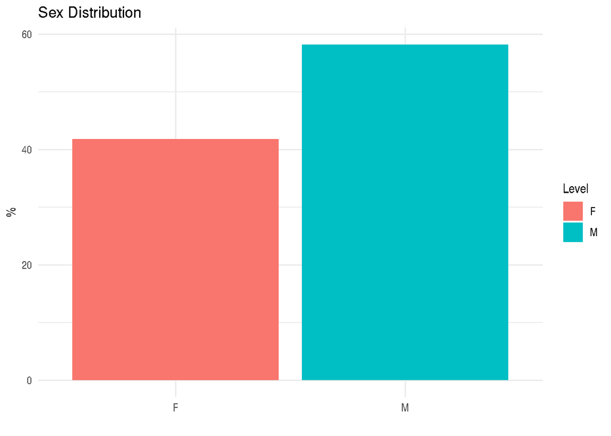

```r
# Plot 1: Sex
ggplot(sex_dist, aes(x = Level, y = Percent, fill = Level)) +
  geom_col() +
  labs(title = "Sex Distribution", x = "", y = "%") +
  theme_minimal()
```

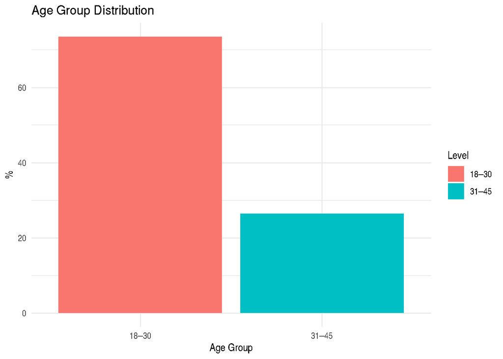

```r
# Plot 2: Age
ggplot(age_dist, aes(x = Level, y = Percent, fill = Level)) +
  geom_col() +
  labs(title = "Age Group Distribution", x = "Age Group", y = "%") +
  theme_minimal()
```

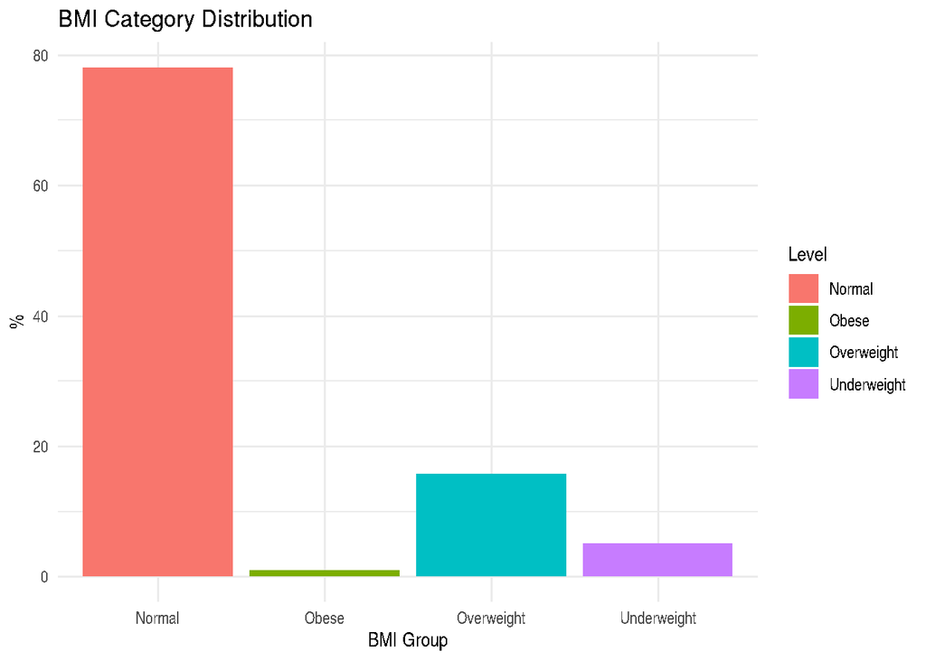

```r
# Plot 3: BMI
ggplot(bmi_dist, aes(x = Level, y = Percent, fill = Level)) +
  geom_col() +
  labs(title = "BMI Category Distribution", x = "BMI Group", y = "%") +
  theme_minimal()
```

### Observations

#### BMI

According to [WHO - Obesity and Overweight Sheet](https://www.who.int/news-room/fact-sheets/detail/obesity-and-overweight) Body Mass Index (BMI) is used to classify individuals based on their body weight relative to height. The standard categories are as follows:

- **Underweight**: A BMI of less than 18.5 indicates underweight status, suggesting insufficient body weight which may be associated with malnutrition or other health risks.
- **Normal weight**: A BMI ranging from **18.5 to 24.9** is considered healthy and is associated with the lowest risk for weight-related health problems.
- **Overweight**: A BMI between **25 and 29.9** indicates excess body weight, which may increase the risk of cardiovascular disease, diabetes, and other conditions.
- **Obese**: A BMI of **30 or more** falls in the obesity range and is associated with significantly higher risks for chronic illnesses including type 2 diabetes, hypertension, and metabolic syndrome.

**We identified 2 samples with BMI values in the obese range (≥ 30)**, which we did not exclude from the healthy reference set because if they are generally healthy it could just be that their BMI above 30 is not pointing out to obesity.

While **overweight (BMI 25–29.9)** and **underweight (BMI < 18.5)** are also not considered ideal from a clinical perspective, we adopted a more flexible approach for these groups as well. If such individuals show no concerning signs in other available health-related variables (e.g., no medications, normal age, no dietary restrictions or chronic conditions), they are retained in the dataset. This allows us to maintain sample diversity.

#### Sex

The sex distribution in our filtered dataset includes approximately **60% male** and **40% female** donors. While not perfectly balanced, this proportion is reasonably close to parity and does not raise immediate concerns for bias in exploratory analyses.

Unless the research question specifically focuses on **sex-related microbiome differences**, or unless downstream analyses show strong sex-associated effects, this level of imbalance is generally acceptable. No indication was given during class that such a distribution would invalidate the dataset. However, we remain aware that sex can influence gut microbiota composition (e.g., via hormonal or metabolic pathways), and we can stratify or adjust for sex in future analyses if needed.

#### Age

The age distribution in our healthy donor set is skewed toward younger individuals, with approximately 74% of samples in the 18–30 age group and the remaining 26% in the 31–45 range. This is not considered problematic; in fact, younger donors are often **preferred** in gut microbiome research and therapeutic applications.

This preference is based on the assumption that younger individuals are less likely to present with age-related chronic conditions, systemic inflammation, or long-term medication use — all factors that can affect microbiome composition. Therefore, this distribution may actually reinforce the biological plausibility of our selected reference set.

#### Medications

Let’s review what medications have some samples reported:

```r
coldata <- as.data.frame(colData(donors_se)) %>%
  tibble::rownames_to_column("sample_id")
medicated_samples <- coldata %>%
  filter(!is.na(medications) & medications != "") %>%
  select(sample_id, sex, medications)

knitr::kable(medicated_samples, caption = "Samples with Reported Medications by Sex")
```

Samples with Reported Medications by Sex

| sample_id | sex | medications |
| --- | --- | --- |
| sample027 | F | Jolessa 015MG-0.03 MG tablet |
| sample122 | F | Implanon- Birth control implant |
| sample019 | F | Jolessa 015MG-0.03 MG tablet |
| sample037 | F | Implanon- Birth control implant |
| sample023 | F | Jolessa 015MG-0.03 MG tablet |
| sample119 | M | Accutane |
| sample125 | F | Birth control |
| sample115 | F | Jolessa 015MG-0.03 MG tablet |
| sample015 | F | Jolessa 015MG-0.03 MG tablet |
| sample017 | F | Jolessa 015MG-0.03 MG tablet |
| sample038 | F | Implanon- Birth control implant |
| sample151 | M | Benzol peroxide |
| sample183 | M | Loratadine 2-4x a month |
| sample144 | F | Lutera- oral contraceptive |
| sample184 | M | Loratadine 2-4x a month |
| sample018 | F | Jolessa 015MG-0.03 MG tablet |
| sample158 | F | birth control |
| sample060 | F | birth control |
| sample026 | F | Jolessa 015MG-0.03 MG tablet |
| sample021 | F | Jolessa 015MG-0.03 MG tablet |
| sample080 | M | occasional advil 1/2-3 months and topical abx every few months |
| sample157 | M | Advil |
| sample025 | F | Jolessa 015MG-0.03 MG tablet |
| sample016 | F | Jolessa 015MG-0.03 MG tablet |
| sample117 | F | Viorele- Birth control |
| sample081 | M | occasional advil 1/2-3 months and topical abx every few months |
| sample106 | F | Implanon- Birth control implant |
| sample024 | F | Jolessa 015MG-0.03 MG tablet |
| sample022 | F | Jolessa 015MG-0.03 MG tablet |
| sample020 | F | Jolessa 015MG-0.03 MG tablet |

Most reported medications were **hormonal contraceptives**, which are common and were retained. One donor reported **Accutane**, a systemic acne treatment with potential gut effects, we suggest this one sample to be excluded. Other cases involved **occasional ibuprofen**, **antihistamines**, and **topical treatments**, which are unlikely to affect the gut microbiome and were **retained**.

#### Allergies

Let’s now review the allergies that the donors reported:

```r
# Make sure sample_id is included
coldata <- as.data.frame(colData(donors_se)) %>%
  tibble::rownames_to_column("sample_id")

# Filter samples with reported allergies
allergy_samples <- coldata %>%
  filter(!is.na(allergies) & allergies != "") %>%
  select(sample_id, allergies)

# Display the table
knitr::kable(allergy_samples, caption = "Samples with Reported Allergies")
```

Samples with Reported Allergies

| sample_id | allergies |
| --- | --- |
| sample087 | pollen |
| sample027 | Penecillian and Amoxicillin |
| sample082 | cat dander |
| sample088 | pollen |
| sample095 | pollen |
| sample084 | Mold |
| sample013 | Cats, Latex |
| sample110 | Cats, Latex |
| sample019 | Penecillian and Amoxicillin |
| sample116 | Mold |
| sample023 | Penecillian and Amoxicillin |
| sample093 | pollen |
| sample008 | Cats, Latex |
| sample119 | Zithromax |
| sample125 | Ceclor |
| sample085 | pollen |
| sample115 | Penecillian and Amoxicillin |
| sample121 | Accutane, Amoxicillin |
| sample015 | Penecillian and Amoxicillin |
| sample089 | pollen |
| sample177 | Pencillin and cats |
| sample017 | Penecillian and Amoxicillin |
| sample153 | pollen |
| sample154 | benzoyl peroxide |
| sample009 | Cats, Latex |
| sample083 | pollen |
| sample094 | pollen |
| sample056 | benzoyl peroxide |
| sample114 | Penecillian |
| sample012 | Cats, Latex |
| sample086 | pollen |
| sample057 | benzoyl peroxide |
| sample183 | Cats, mild dust allergies |
| sample163 | Seasonal allergies and cats |
| sample178 | Pencillin and cats |
| sample144 | Penicillin, Sulfad rugs |
| sample061 | cat dander |
| sample010 | Cats, Latex |
| sample184 | Cats, mild dust allergies |
| sample018 | Penecillian and Amoxicillin |
| sample005 | Cats, Latex |
| sample164 | Seasonal allergies and cats |
| sample062 | cat dander |
| sample141 | Bees |
| sample078 | Seasonal/ pollen |
| sample091 | pollen |
| sample123 | Seasonal allergies |
| sample026 | Penecillian and Amoxicillin |
| sample196 | Asthma, Dogs, Cats |
| sample143 | Seasonal allergies |
| sample135 | Pencillin |
| sample021 | Penecillian and Amoxicillin |
| sample140 | Seasonal allergies |
| sample159 | cat dander |
| sample131 | Seasonal allergies |
| sample195 | Asthma, Dogs, Cats |
| sample134 | summer allergies |
| sample090 | pollen |
| sample073 | Seasonal allergies |
| sample072 | Seasonal allergies |
| sample014 | Cats, Latex |
| sample145 | Dust |
| sample006 | Cats, Latex |
| sample025 | Penecillian and Amoxicillin |
| sample016 | Penecillian and Amoxicillin |
| sample092 | pollen |
| sample109 | Seasonal allergies |
| sample024 | Penecillian and Amoxicillin |
| sample050 | summer allergies |
| sample011 | Cats, Latex |
| sample007 | Cats, Latex |
| sample022 | Penecillian and Amoxicillin |
| sample020 | Penecillian and Amoxicillin |

**Most reported allergies were environmental** (e.g., pollen, dust, cats) or to **common medications.** These are not exclusionary in microbiome reference studies. **Two samples reported asthma**, which may be considered borderline based on immune involvement, but were retained unless further signs of bad overall health were found.

### Final Suggestion for Filtering

To maintain a high-quality reference set while retaining as many plausible healthy samples as possible, we followed a conservative but practical filtering approach. As stated in the original study:

> *“Stool donors providing the material are rigorously screened for diseases and disorders with a potential microbiome etiology, and they are likely healthier than the controls in most microbiome datasets.”*

Based on this, we propose the following exclusion:

- The **1 sample with no reported BMI**, since BMI is a core variable for health assessment.

All other samples are retained, including those with reported hormonal birth control, common allergies, or occasional NSAID use, as these are not expected to substantially alter microbiome composition.

With this **refined cohort**, we proceed to estimate **alpha diversity metrics** to characterize the microbial richness and evenness within this healthy donor reference set.

```r
# Extract metadata
coldata <- as.data.frame(colData(donors_se)) %>%
  tibble::rownames_to_column("sample_id") %>%
  mutate(bmi = as.numeric(bmi),
         medications = tolower(medications))

# Identify only samples with missing BMI
excluded_samples <- coldata %>%
  filter(is.na(bmi)) %>%
  pull(sample_id)

# Subset donors_se to only include samples with reported BMI
donors_se_filtered <- donors_se[, !colnames(donors_se) %in% excluded_samples]
```

## Alpha Diversity

### Rarefaction

```r
# Assuming you have sample_depths already:
sample_depths <- rowSums(t(assays(donors_se_filtered)$counts))

# Create a vector of thresholds to test
thresholds <- c(5000, 10000, 15000, 20000, 50000)

# Calculate number of samples above each threshold
threshold_df <- data.frame(
  Threshold = thresholds,
  Retained = sapply(thresholds, function(t) sum(sample_depths >= t))
) %>%
  mutate(
    Total = length(sample_depths),
    Removed = Total - Retained,
    Retained_Percent = round(Retained / Total * 100, 1)
  )

# Display the summary
knitr::kable(threshold_df, caption = "Sample Retention by Rarefaction Threshold")
```

Sample Retention by Rarefaction Threshold

| Threshold | Retained | Total | Removed | Retained_Percent |
| --- | --- | --- | --- | --- |
| 5000 | 184 | 196 | 12 | 93.9 |
| 10000 | 157 | 196 | 39 | 80.1 |
| 15000 | 100 | 196 | 96 | 51.0 |
| 20000 | 61 | 196 | 135 | 31.1 |
| 50000 | 25 | 196 | 171 | 12.8 |

**Outlier Removal Based on ASV Richness** To ensure the reliability of diversity estimates, we visualized sample richness (i.e., number of observed ASVs) across all samples using a boxplot. A small subset of samples exhibited abnormally high richness, far exceeding the upper quartile (e.g., >2000 ASVs), which strongly suggests possible technical artifacts such as cross-contamination, index hopping, or sequencing noise. These extreme outliers were excluded from further rarefaction and diversity analyses to avoid skewing overall patterns.

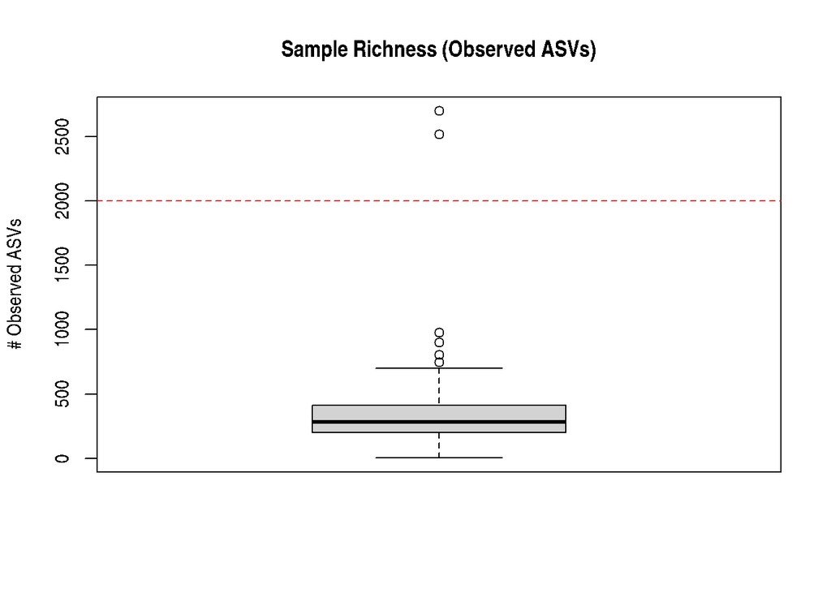

```r
# Step 1: Extract the OTU matrix
otu_mat <- assays(donors_se_filtered)$counts

# Step 2: Transpose so samples are rows
otu_t <- t(otu_mat)

# Step 3: Calculate observed richness (number of ASVs) per sample
sample_richness <- specnumber(otu_t)

# Step 4: Visualize with a boxplot
boxplot(
  sample_richness,
  main = "Sample Richness (Observed ASVs)",
  ylab = "# Observed ASVs"
)
abline(h = 2000, col = "red", lty = 2)  # add threshold line
```

```r
# Step 5: Filter out high-richness outliers
high_richness_samples <- names(sample_richness[sample_richness > 2000])
otu_t_filtered <- otu_t[sample_richness <= 2000, ]

# Log removed samples and their names
cat("Removed", length(high_richness_samples), "samples with >2000 ASVs:\n")
```

```
## Removed 2 samples with >2000 ASVs:
```

```r
cat(paste(high_richness_samples, collapse = ", "), "\n")
```

```
## sample099, sample106
```

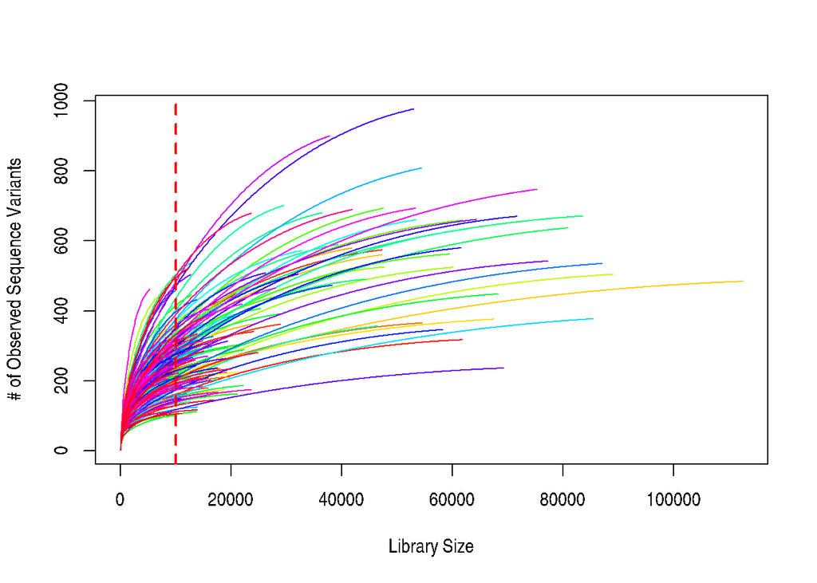

```r
library(vegan)
options(scipen = 999)

# Plot rarefaction curves using filtered OTU matrix (samples as rows)
rarecurve(
  otu_t_filtered,           # after ASV outlier removal
  step = 100,
  col = rainbow(nrow(otu_t_filtered)),
  label = FALSE,
  xlab = "Library Size",
  ylab = "# of Observed Sequence Variants",
  cex = 0.6
)

# Add red vertical line at 5,000
abline(v = 10000, col = "red", lwd = 2, lty = 2)
```

Although higher thresholds are sometimes used in microbiome studies and were initially considered in our analysis, **we opted to explore a the standard threshold of 10000 reads to better understand how reduced depth might impact diversity metrics.**

```r
# Step 1: Filter for samples with at least 10,000 reads
sample_depths_filtered <- rowSums(otu_t_filtered)
otu_t_filtered_depth <- otu_t_filtered[sample_depths_filtered >= 10000, ]

# Step 2: Rarefy to exactly 10,000 reads
set.seed(42)  # for reproducibility
otu_rarefied <- rrarefy(otu_t_filtered_depth, sample = 10000)

# Step 3: Transpose back (samples as columns, OTUs as rows)
otu_rarefied <- t(otu_rarefied)
```

```r
# Compute metrics from rarefied OTU table (samples as columns, so transpose)
alpha_df <- data.frame(
  sample_id = colnames(otu_rarefied),
  shannon = diversity(t(otu_rarefied), index = "shannon"),
  simpson = diversity(t(otu_rarefied), index = "simpson"),
  invsimpson = diversity(t(otu_rarefied), index = "invsimpson"),
  observed = specnumber(t(otu_rarefied))
) %>%
  mutate(
    evenness = shannon / log(observed)
  )
```

### Metrics

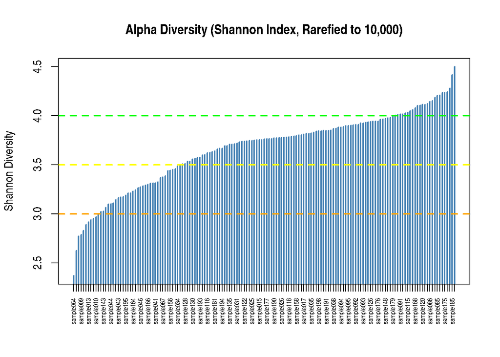

```r
# Extract and sort Shannon diversity values
shannon <- alpha_df$shannon
names(shannon) <- alpha_df$sample_id
shannon <- sort(shannon)

# Plot sorted Shannon index as vertical bars
plot(
  shannon,
  type = "h",                        # vertical lines
  lwd = 2,
  col = "steelblue",
  ylab = "Shannon Diversity",
  xlab = "",
  main = "Alpha Diversity (Shannon Index, Rarefied to 10,000)",
  xaxt = "n"                         # remove default x-axis
)

# Add sample names rotated for readability
axis(1, at = 1:length(shannon), labels = names(shannon), las = 2, cex.axis = 0.6)

# Add horizontal red threshold line at Shannon = 3
abline(h = 3, col = "orange", lwd = 2, lty = 2)

# Add horizontal red threshold line at Shannon = 3.5
abline(h = 3.5, col = "yellow", lwd = 2, lty = 2)

# Add horizontal red threshold line at Shannon = 4
abline(h = 4, col = "green", lwd = 2, lty = 2)
```

```r
quantile(alpha_df$shannon, probs = c(0, 0.10, 0.20, 0.30, 0.40, 0.50, 0.60, 0.70, 0.80, 0.90, 1))
```

```
##       0%      10%      20%      30%      40%      50%      60%      70%
## 2.369492 3.104045 3.307998 3.533004 3.694346 3.762028 3.806287 3.883252
##      80%      90%     100%
## 3.948144 4.093423 4.499308
```

### Initial Comments

To contextualize this, we compared our values with those reported in two major studies:

- The [**Global Human Gut Microbiome Compendium** (Cell, 2024)](https://www.sciencedirect.com/science/article/pii/S0092867424014302) analyzing over 150,000 samples globally, reported a **median Shannon index of 2.33**, with **considerable variability across regions and populations.** However, this dataset was **not restricted to healthy individuals**, which likely accounts for the lower central tendency.
- The [**Nature Communications study** (Manor et al., 2020)](https://pmc.ncbi.nlm.nih.gov/articles/PMC7562722/) based on ~3,400 self-reported healthy U.S. adults, reported Shannon diversity values ranging from **~2 to 5.5**, with a **visually estimated median around 4.0** at a **rarefaction depth of 50,000 reads.** Notably, their cohort included individuals with a **mean BMI of 27 ± 6**, meaning it likely included **obese individuals.**

Samples excluded because of missing data and extreme observed ASV values are **sample063, sample099, sample106.**

```r
# Convert colData to a tibble with sample_id as a column
sample_metadata <- as.data.frame(colData(donors_se)) %>%
  tibble::rownames_to_column("sample_id")

# Exclude specific samples
excluded <- c("sample063", "sample099", "sample106")
sample_metadata_filtered <- sample_metadata %>%
  filter(!sample_id %in% excluded)

# Create useful download URLs (optional but helpful for retrieval)
sample_metadata_filtered <- sample_metadata_filtered %>%
  mutate(
    sample_url = paste0("https://www.ebi.ac.uk/ena/browser/view/", sample_accession),
    experiment_url = paste0("https://www.ebi.ac.uk/ena/browser/view/", experiment_accession),
    run_url = paste0("https://www.ebi.ac.uk/ena/browser/view/", run_accession)
  )

# Write to CSV
write.csv(sample_metadata_filtered, "sample_metadata_links.csv", row.names = FALSE)
```